# Project H2

Jeffrey Nguyen, Luka Marceta, Quang Nguyen, Liza Moore

2/21/2021

# INFO 201 Course Project

# Project Domain: School Shootings and Income

Jeffrey Nguyen, Luka Marceta, Quang Nguyen, Liza Moore

## Section 1

### Problem Domain

Our proposal seeks to investigate the relationship between regional wealth and the recorded number of school shootings. Our group has defined a school shooting as *“any time a gun goes off in an academic setting”*. The Center for Homeland Security has compiled the only comprehensive school shooting incident report in America. Popular press organizations as well as American think tanks commonly reference this dataset. However, we acknowledge that defining “school shooting” abstract and there are several social, political, and cultural facets that need to be taken into consideration when analyzing this data. Additionally, the creators of this dataset acknowledge the limitations of this list, disclosing that the ambiguity of a school shooting requires a compassionate mindset to take in myriad variables. Casting a “wide net” to catch as many incidents as possible. The phenomena recorded in each incident are diverse, including “Bullying,” “Illegal Activity,” “Indiscriminate/Targeted”, “Gang Affiliation”.

Moreover, each incident has a reliability score that is found by assessing the credibility of the source The other data set we gathered as a proxy to the wealth of each school is a comprehensive list of the unemployment and median household income in a given state and county. The data set is from the US Department of Agriculture. This data set was gathered overtime from each specific region from 2000-2019, using census data as well as local data from authorities. Overall, it provides a comprehensive list that gives strong economic data by county. Although our group’s intention is to merely summarize and consolidate wealth and school shooting incidents, we are interested in whether there are any differences in motivation, weapon, or legal ramifications. Understanding of economic and financial distress relative to school shooting and violence is important to understand the given report.

We have included the following articles in order to contextualize our exploratory report and the sensitive nature of the datum.

#### [Income inequality and mass shootings in the United States](https://bmcpublichealth.biomedcentral.com/articles/10.1186/s12889-019-7490-x) [Income Inequality, Household](https://www.ncbi.nlm.nih.gov/pmc/articles/PMC6199901/)

#### [Income, and Mass Shooting in the United States](https://www.ncbi.nlm.nih.gov/pmc/articles/PMC6199901/)

## Section 2

### Data Description

#### [K-12 School Shooting comprehensive list](https://www.chds.us/ssdb/data-map/)

- Description of Data set
  - Providing information on school shooting from 1970 to 2020 from the school and the date to more strenuous information including narrative and summary.
- How data was collected
  1. Preliminary research and merging multiple data sources
  - From “US Secret Service, FBI, and Department of Education; media or advocacy groups including The Washington Post, CNN, Gun Violence Archive, Everytown for Gun Safety, Education Weekly, and Mother Jones; and websites or blogs including Columbines Angels, Wikipedia, schoolshootingdatabase.com, and schoolshootingtracker.com.”
  2. Detailed research
  - Assessment of situation and detailed information from teachers to students shot and going into depth on the exact circumstances and motivations that might have prompted the event.
  3. Score reliability of data
  - Reliability on information ranging from (1-5) weakest to strongest:
    1. Blogs
    2. Single newspaper articles or online news
    3. Multiple News Sources
    4. Hundreds of News Sources or Statement/Interview from law enforcement
    5. Court Records or Police Reports

#### [Median household income and Unemployment for US, States, and Counties](https://www.ers.usda.gov/data-products/county-level-data-sets/download-data/)

- Description of Data set
  - Information on the household income and unemployment in a given county, state, and nationally. Provided information from rate to actual numbers in those respected locations.
- How data was collected
  - Data was collected by the US Department of Agricultures Economic Research Service.
    - Data was collected using Department of Labor and other US Department data and putting all the data gathered by the agencies in a nuanced list for use.

### Data Samples

#### School Shooting Data Sample

This data sample shows the date of the school shooting and the school where the shooting occured. This data further goes into depth describing the situation of the shooting explaining whether or not the shoot was accidental or had motives. Finally it includes the outcome of the victims in the shooting from shots that had no impact on people to wounded shots that injured and finally fatal shots that killed.

*Data Wrangling*

First, we edited the casualties data to show the number of wounded, fatal, none, and minor injuries for each shooting and joined it with the SSDB data. Following that we used US city data that contains county_fips, lat, lng, and location. Joining that together with the SSDB, to give us accurate data with locations. Following that merged the data with Unemployment.

#### Unemployment/Median Household Income Data Sample

This sample data set shows the economic situation of each area in the United States. It provides the location with the given county and state in the area_name. The unemployment rate is provided in each county in the United States as well as nationally. The median household income of each area is also provided in this data set. Finally, there is the median household income percentage as it relates to state. This information shows how much lower or higher that county’s median household income is relative to their respectful state average median household income.

*Data Wrangling*

First, we selected unemployment data throughout the years and included the median household income and percentage. Following that we also included data on low, medium, and high income areas separating it out by relative percentage with 85% and lower being lower income and 85% to 115% being medium income and 115% and higher being high income areas. Following that merged data with SSDB data.

## 2.2 Summary Statistics

Although both the US Department of Agricultural Economic Research Unemployment data set and the K-12 School Shooting data set both span over several years, our data visualization and many of our question analysis revolves around 2019 due to the comprehensive analysis on wealth and income in the Unemployment data set. Here is the overview of the variables we have decided to highlight in our summary statistics.

School Shootings

- In 2019, there were:
  - 113 school shootings
- resulting in:
  - 24 fatalities
  - 86 wounded
- The types of weapons used:
  - Handgun
  - Rifle
  - Shotgun
- The 2019 shootings took place in:
  - 93 cities
  - 93 counties

### Unemployment Data

- In 2019, the national average unemployment rate:
  - 3.7
- Kusilvak Census Area, AK had the highest average unemployment rate:
  - 19.3
- Loudoun County, VA had the highest median income:
  - 1.51806^{5}
- Los Alamos County, NM had the highest median income relative to median state income
  - 234.5
- The national median household income in 2019:
  - 6.5712^{4}

### Graphs

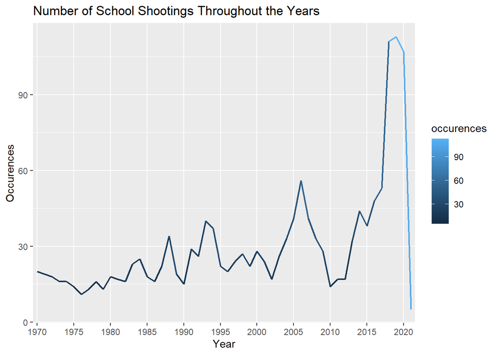

This graph explains the number of school shootings from 1970 to 2020. The y-axis represents the number of shootings in occurrences and the x-axis represents the time in years.

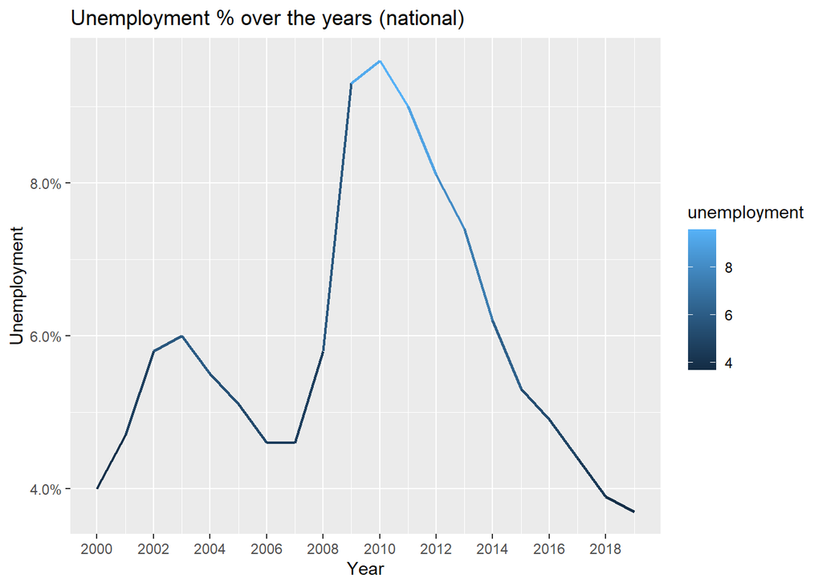

This graph shows the unemployment rate from 2000 to 2019. The y-axis represents the unemployment rate by percentage, the x-axis represents time in years.

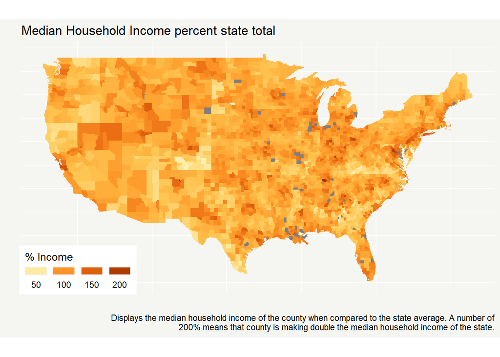

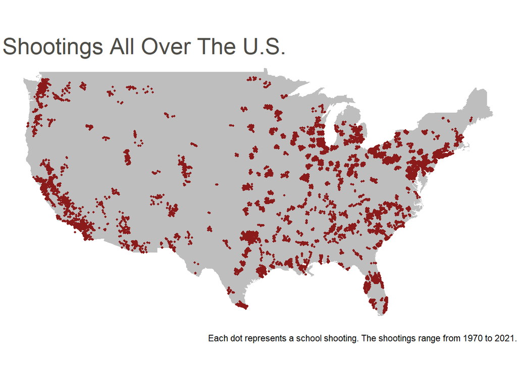

### Outliers

#### School Shooting Casualties: We found several extreme scores in the amount of casualties from school shooting incidents.

| Date | School | Casualty |
| --- | --- | --- |
| 1986-05-16 | Cokeville Elementary School | 74 |
| 1999-04-20 | Columbine High School | 37 |
| 1989-01-17 | Cleveland Elementary School | 35 |
| 2018-02-14 | Marjory Stoneman Douglas High School | 34 |
| 1998-05-21 | Thurston High School | 27 |

Overall there are a couple of outliers in the Casualties that stem from mass shooting. These outliers signify many of the mass shootings at schools in recent years and are some of the most newsworthy stories of the last 50 years. Casualties = Fatal injuries + Wounded injuries.

#### Unemployment: we found extreme outliers using the methodology in the package “statix”

| area_name | Med_HH_Income_Percent_of_State_Total_2019 |
| --- | --- |
| Forsyth County, GA | 182.9 |
| Hamilton County, IN | 186.9 |
| Oldham County, KY | 193.6 |
| Los Alamos County, NM | 234.5 |
| Delaware County, OH | 187.8 |
| Williamson County, TN | 213.5 |
| Loudoun County, VA | 198.5 |
| Falls Church city, VA | 180.3 |

Overall, all signify some of the richest counties relative to their respective states with many above the 180% threshold. Many of the outliers are also a byproduct of the poor states that they are apart off.

## Section 3

### Analysis Questions

#### 1. Are rifles more prevalent in shootings in higher income areas?

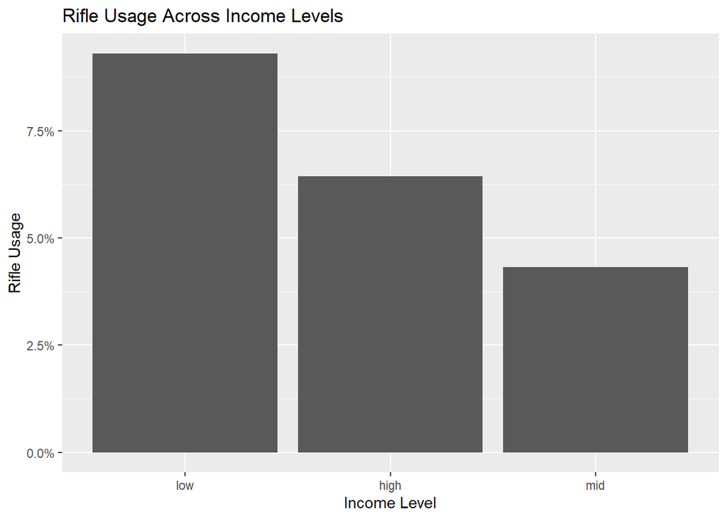

##### Introduction:

We took each occurrence of a rifle or multiple rifle school shooting and paired it with the median household income percentage for the occurrence’s county fips.

##### Method:

We had to trim the data set to the specific columns needed. From the School Shooting database we needed: county_fips, and weapontype. From the unemployment data I selected: county_fips, Med_HH_Income_Percent_of_State_Total_2019. Then we combined the datasets for easier wrangling. Because “higher income” does not have a specific definition, we defined “low, medium, and high income”.

The counties with low income had an average household income that was 15% below that state average (85%). The counties with middle income had an average income between 85% to 115% of state’s income. The counties with the highest income had average household incomes 115% of the state’s average income

#### 2. Does income affect the number of casualties in a mass shooting?

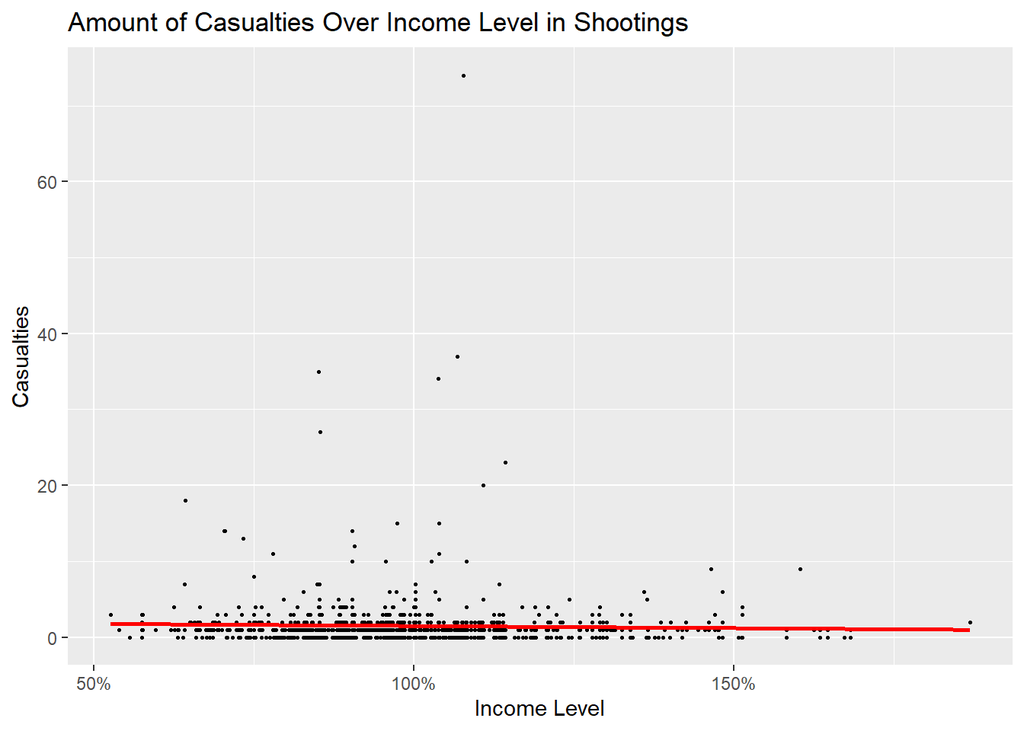

##### Introduction:

Income is defined as household income for 2019 and casualties is defined as injuries and fatalities sustained during the school shooting.

##### Method:

We took the casualties for each school shooting and paired them with the median household income percentage for the shooting’s county fip. We trimmed each data set. For SSDB: county_fips, fatal, wounded, minor injuries, none. And For unemployment: county_fips, med_HH_income % state total

##### Results:

There was no statistically significant difference between income and casualties in mass shootings as shown with the flat trend line.

3. Of high income areas, what are the occurrences of shootings at the different levels of schools?

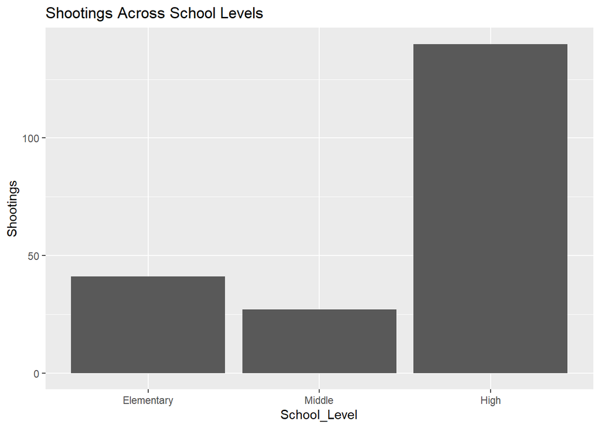

##### Introduction:

Finding the school level of each school is already provided on the SSDB. Therefore using that information to find the shooting data relative to income level.

##### Method:

First we found Higher Income Areaswhere the average income is >100% of state income. Then found the amount of shootings by each group. Moreover, we found the high median household income percentage baseline by filtering for incomes over 100%, then found the school level for each shooting and paired the two together by county fips.

4. Does income influence whether or not officers are involved in a school shooting?

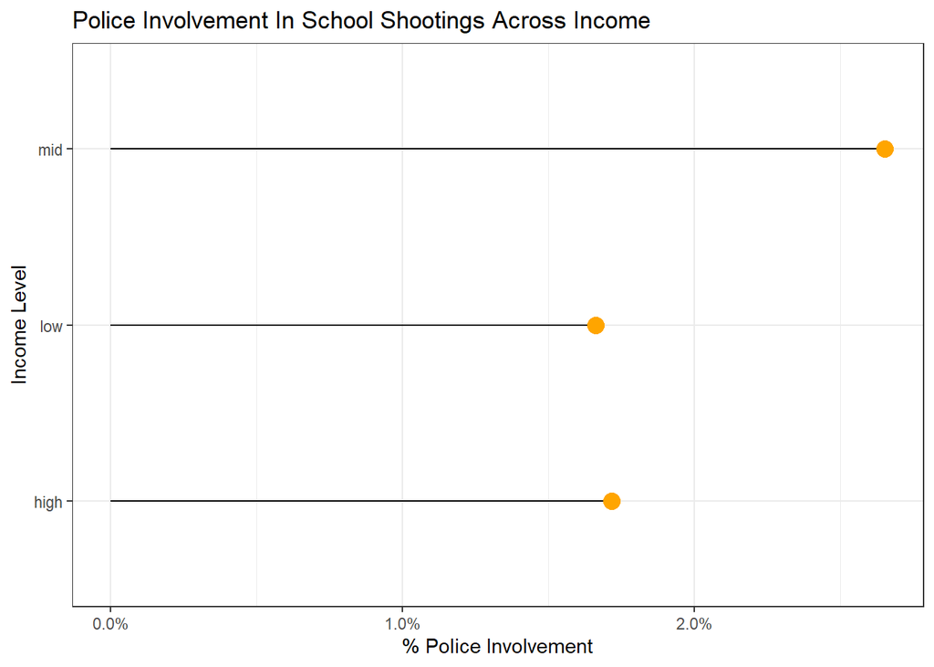

##### Introduction:

The officers information is given in the SSDB. Using the income data to find school relative to income to find answer.

##### Method:

After defining low, middle, and high income areas, we found the police involvement rate by income bracket. The lollipop chart represents what percentage of shootings officers were present at.

##### Results:

The most surprising aspect of the analysis was found that majority of the times, officers were not involved in the shooting incident. Although income is not independent from the rate of police involvement, there is no substantial difference between the income areas.